# Ocean Data Bank (ODB) 海洋生物資料庫查詢說明

cywhale

2018-10-19

- 科技部海洋學門資料庫 (ODB) 生物資料查詢介面使用說明
- It’s a manual for web page [bio.odb.ntu.edu.tw/query](http://bio.odb.ntu.edu.tw/query/) to query bio-database in Ocean Data Bank (**ODB**), Institute of Oceanography, National Taiwan University (**IONTU**) and the Ministry of Science and Technology (**MOST**), Taiwan.
- See the [manual in English](http://bio.odb.ntu.edu.tw/index_en.html).

#### 參考網站

- [ODB官網](http://www.odb.ntu.edu.tw/)
- 欲申請相關資料，作業程序均依[科技部所規範釋出規定](http://www.odb.ntu.edu.tw/?page_id=379)辦理。
- 聯繫 [相關資料維護之技術員](http://www.odb.ntu.edu.tw/?page_id=26)
- [技術引用](http://bio.odb.ntu.edu.tw/index_tech_citations.html)

[figure not shown]

#### 首頁說明

- [bio.odb.ntu.edu.tw/query](http://bio.odb.ntu.edu.tw/query/) 主要功能包括：
1. 海洋生物**地理分布資訊**查詢
   - 以浮游動物（**橈足類**等）與**仔稚魚** (larval fish) 等海洋生物物種為主，可依學名查詢其地理分布(主要在亞洲西太平洋區域）。
   - 資料來源主要為 ODB 生物資料庫，自科技部研究計畫成果、論文期刊、研究者資料分享中擷取在台灣周遭海域 (10-40ﾟN, 105-135ﾟE) 海洋生物拖網資料，並經授權匯入此區域內 [COPEPOD (Coastal and Oceanic Plankton Ecology, Production and Observation Database)](https://www.st.nmfs.noaa.gov/copepod/) 海洋浮游生物資料庫部分資料。
   - 查詢物種地理分布將自動引入 OBIS (Ocean Biodiversity Information System, obis.org) API 可擷取之開放資料，請參考 [OBIS 官網對資料規範與 API 說明](http://obis.org/manual/)。
   - 可同時查詢物種在表層海溫(SST)、鹽度(Salinity)上之分布，有助於了解物種分布所對應之水體溫度、鹽度適應性範圍。
2. 區域性海洋生物**物種多樣性資訊**呈現
   - 涵蓋上述 ODB 生物資料庫中具有豐度(Abundance) 之量化數據，可查詢各採樣站或經緯度網格之物種組成。
   - **更新** 提供區域物種組成學名列表開放資料下載, 且提供 **繪製區塊**（多邊形）模式查詢。
   - 可同時分析物種群聚豐度分布與環境因子相關性，除了緯度、經度、海深之外，還包括表層海溫、鹽度、葉綠素濃度（以上為0.5°網格資料，鹽度採用NOAA NCEP GODAS資料庫，表層海溫與葉綠素濃度採NASA Earth Observations 公開之網格化統計數據）。
3. 依查詢條件**提供資料申請**便捷服務、下載分析圖檔與開放資料（物種列表）
   - 依所查詢各採樣站或經緯度網格之物種組成，可下載物種列表或分析圖檔(PNG)。若需要其原始數據，可直接將查詢條件下載或寄送相關之ODB技術員。

[figure not shown]

#### 使用說明

- 首頁提供中文(TW)、英文(EN)語言切換。底圖顏色顯示地形變化；底圖可由 地圖右上方【圖層】按鈕中選擇切換，ODB WMS 服務也提供 etopo1 水深底圖。地圖上圓形站點顯示目前 ODB 所有資料之採樣點位，顏色呈現採樣季節（點選該點位可顯示相關資訊）。首頁左上方提供3個介面切換按鈕：Toggle Menu【開闔選單】可開關【設定】選單，Advanced analyses【進階分析】可展摺有關環境因子相關之格點分析，以及繪製區塊查詢切換可開關**繪製區塊**（多邊形）模式查詢。
1. 查詢海洋生物地理分布資訊
   - **學名輸入**：在首頁空白查詢欄位中鍵入所需查詢之學名，將自動跳出最接近之候選物種供選擇。亦可經由 Tree list【物種分類群】依所需物種所處之分類群（點開樹狀圖上三角形頁籤）選擇，按住 ‘Ctrl’ 鍵後可用滑鼠複選，選好按下 Apply【完成】關閉樹狀選單。輸入之學名確認後，即可按 Query【查詢】。
   - **查詢結果**：每一點位均可再點選顯示其**資料引證**與其他資訊。查詢後將同時顯示結果列表，列表中錨點符號可點選快速跳至地圖上該點位；列表亦可依條件進一步篩選結果。
   - **溫、鹽梯度分布**：切換Advanced analyses【進階分析】介面，可顯示所查詢物種在溫、鹽梯度之分布（若未顯示可點選【送出分析】）。可進一步刪、選地圖中藍色網格將格點移出或加入溫鹽度梯度分布分析；網格大小可由上方選鈕控制。選擇完畢點選【送出分析】。可選擇**溫鹽梯度**或**地理分布**【下載圖檔】（但切換選擇須重新【送出分析】）。

```
* 注意：目前本功能僅供一次查詢最多3個物種，以不同顏色呈現其分布。輸入之學名須為"科"級以下（科、屬、種），學名比對為精確比對，亦即查詢科名、屬名並不會包含該科或該屬以下所有物種，僅會查詢採樣資料中鑑定至科或屬(spp.) 之物種。
```

```r
# 備註：任一物種地理分布查詢結果，並不代表該物種之所有分布範圍，僅反映 ODB 與所引入外部資料所擁有該物種的資料範圍。
```

2. 查詢區域性海洋生物物種多樣性資訊
   - 按 Setting【設定】進入進階功能選單。以下查詢條件均可空白（即代表不限），設定所需條件後按 Apply【完成】關閉選單。
     - Taxonomic groups【限定物種分類群】：侷限分析組成對象之物種僅在部分主要分類群之下（可複選），空白為不限。
     - Sample date range【採樣日期範圍】：侷限分析之採樣日期範圍。
     - Depth【採樣深度範圍】：侷限分析之採樣深度範圍，單位為公尺。
     - Mesh size【拖網網目範圍】：侷限採樣時所使用拖網網目範圍，單位為毫米 (mm)。
     - Sample season【採樣季節】：侷限分析之採樣季節（可複選）。
     - Grid【網格化】：分析時採用原座標 (Raw) 或0.25度、0.5度、1度、2度座標。分析結果僅列表顯示網格化後座標，在地圖上仍以原座標呈現。同一網格內的各站位，點選其物種組成（呈現於餅圖 pie chart）皆一致。
     - Taxon level【分類階層】：分析時所採用之最小分類階層，比如選擇屬 (genus)，則同屬物種都將被視為同一分類群，這些同屬種位於同一站點或網格之豐度將被加總。點選各站位物種組成（餅圖 pie chart）皆只呈現該分類階層之組成。
     - Abundance unit【物種豐度單位】：ODB 生物資料庫大部分資料之計量單位均為每立方公尺個體數 (per/m3)，僅少部分底棲物種為每平方公尺個體數 (per/m2)。若物種分類群選擇限定demersal fish（底棲魚）， 分析時會自動限定單位為每平方公尺個體數。
     - Abundance/Occurrence【豐度/頻度分析】：選擇 Abundance（相對豐度）分析，將使用對數化之網格平均豐度以計算該網格物種組成之比例。若選擇Occurrence（頻度）分析，則將計算該網格內所採樣到該物種的拖網次數。
   - 完成 Setting【設定】選單後回到首頁，按 Analyze species composition【分析各站物種組成】，即可進行分析。
   - 按鈕: ‘切換為各站或各多邊形內物種列表’ 分析所得物種（及分類階層）列表，且可用旁’下載’按鈕下載此開放資料。

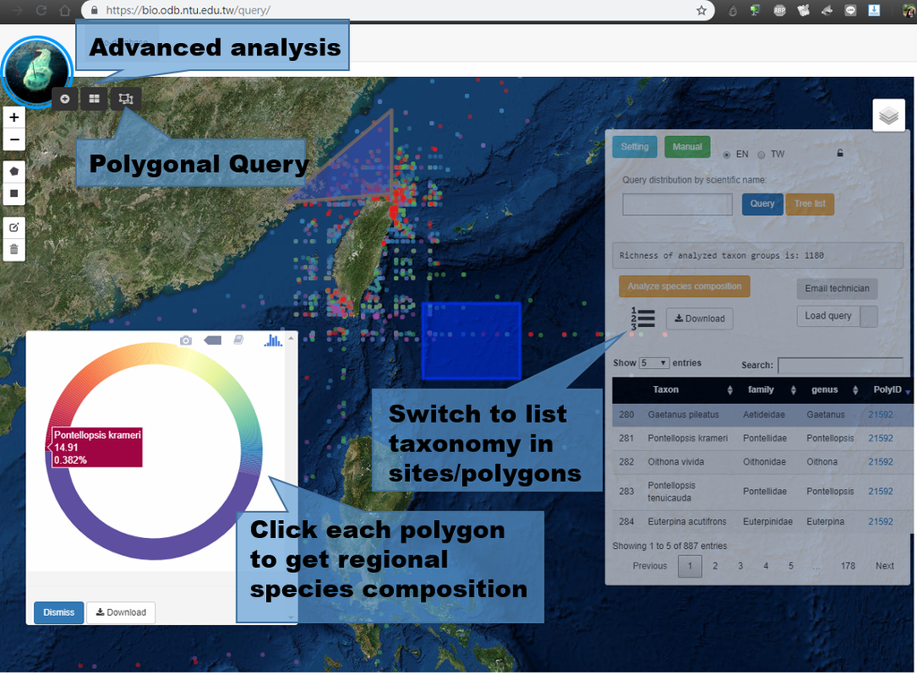

3. 多邊形區塊查詢
   - 左側 **繪圖工具列**：為地圖加上一些多邊形或方形查詢區塊。在按下分析按鈕之後，繪製所欲區塊接著按下頂端繪製區塊查詢切換按鈕開啟（或關閉）區塊查詢模式。當開啟此模式，每個區塊內物種列表與相對豐度 (RA) 會顯示在表中，而點選地圖上區塊會顯示餅圖。
   - 點選上述’切換為各站或各多邊形內物種列表’按鈕之後下載各區域資料。
   - 再按一次頂端模式開關按鈕即關閉此區塊查詢模式。
4. 海洋環境因子進階分析
   - **環境因子相關性分析**：切換Advanced analyses【進階分析】介面，可顯示所分析分類群和環境因子相關性。環境因子可透過上方下拉式選單控制（可複選），若未選擇則呈現和緯度、經度、海深相關性。
   - 可進一步刪、選地圖中藍色網格將格點移出或加入環境因子相關性分析；網格大小可由上方選鈕控制。選擇完畢點選【送出分析】。
   - **相關分析**亦可【下載圖檔】。

```
* 分析結果以列表與地圖點位展示，進一步點選點位，可呈現該站物種（依所選分類階層）組成餅圖 (pie chart)。顏色呈現豐度或頻度排名於該點位或網格前50名(於點位內)或前250名(於區塊內)物種，滑鼠移至各色階之上，將顯示其學名與所佔比例。
```

```r
# 備註：任一點位或網格物種組成分析結果，仍存在各點位採樣次數所造成之系統性偏差，對於物種多樣性與歧異度之估算，必須再經由統計上的校正。目前為初步呈現，我們將進一步提供物種歧異度分析。
```

3. 依查詢條件提出原始資料申請
   - 按 Email technician【郵寄技術員】可將功能2之查詢條件自動附加於電子郵件之中。寄送相關之技術員後，技術員即可依此條件調用所需之原始資料。另外可下載此檔案或載入過去查詢之檔案，重新分析。
   - 惟資料申請須依相關作業程序 完成核可與申請，申請人仍須另外寄送**申請人簽章後的資料申請單PDF**給技術員。

關於：本網站以R Shiny與相關開源技術製作（查看 [本站技術引用](http://bio.odb.ntu.edu.tw/index_tech_citations.html) ），若您對相關資料、技術細節想進一步了解，或欲回饋使用意見，請來信 cyweng24@ntu.edu.tw，或者在[作者github上開設新議題](https://github.com/cywhale/ODB/issues)。